# Анализ данных pollutio

# Загрука данных

```r
df <- read.csv("../stat2021_sm/POLLUTIO.STD/POLLUTIO.txt", sep = "\t", dec = ",")
df |> head(5)
```

|  | PREC | JANT | JULT | OVR65 | POPN | EDUC | HOUS | DENS | NONW | WWDRK | POOR | HC | NOX | SO2 | HUMID | MORT |
| --- | --- | --- | --- | --- | --- | --- | --- | --- | --- | --- | --- | --- | --- | --- | --- | --- |
| 1 | 36 | 27 | 71 | 8.1 | 3.34 | 11.4 | 81.5 | 3243 | 8.8 | 42.6 | 11.7 | 21 | 15 | 59 | 59 | 921.870 |
| 2 | 35 | 23 | 72 | 11.1 | 3.14 | 11.0 | 78.8 | 4281 | 3.5 | 50.7 | 14.4 | 8 | 10 | 39 | 57 | 997.875 |
| 3 | 44 | 29 | 74 | 10.4 | 3.21 | 9.8 | 81.6 | 4260 | 0.8 | 39.4 | 12.4 | 6 | 6 | 33 | 54 | 962.354 |
| 4 | 47 | 45 | 79 | 6.5 | 3.41 | 11.1 | 77.5 | 3125 | 27.1 | 50.2 | 20.6 | 18 | 8 | 24 | 56 | 982.291 |
| 5 | 43 | 35 | 77 | 7.6 | 3.44 | 9.6 | 84.6 | 6441 | 24.4 | 43.7 | 14.3 | 43 | 38 | 206 | 55 | 1071.289 |

16 признаков, 60 наблюдений.

## Описание признаков:

1. *PREC* - Среднегодовое количество осадков в дюймах - количественный, дискретный (5 значений равны моде)
2. *JANT* - Средняя температура января в градусах по фаренгейту - количественный дискретный (5 значений равны моде)
3. *JULT* - То же для Июля - количественный дискретный (11 значений равны моде)
4. *OVR65* - Процент населения на 1960 г. в возрасте 65 лет и старше - количественный непрерывный
5. *POPN* - Средний размер домохозяйства (среднее количество людей на домохозяйство) - количественный непрерывный
6. *EDUC* - Средняя продолжительность обучения в школе для лиц старше 22 лет в годах - количественный непрерывный
7. *HOUS* - Процент жилья, отвечающего требованиям безопасности и имеющего все удобства - количественный непрерывный
8. *DENS* - Численность населения на квадратную милю в урбанизированных районах на 1960 г. - количественный непрерывный
9. *NONW* - Процент небелого населения в урбанизированных районах на 1960 г. - количественный непрерывный
10. *WWDRK* - Процент людей занятых в профессиях “белых воротничков” - количественный непрерывный
11. *POOR* - Процент семей с доходом меньше $3000 - количественный непрерывный
12. *HC* - Относительный потенциал загрязнения углеводородами - количественный дискретный (5 значений равны моде)
13. *NOX* - То же для оксидов азота - количественный дискретный (7 значений равны моде)
14. *SO2* - То же для диоксида серы - количественный дискретный (6 значений равны моде)
15. *HUMID* - Среднегодовая относительная влажность воздуха в 1PM в процентах - количественный дискретный (11 значений равны моде)
16. *MORT* - Общий показатель смертности с поправкой на возраст на 100 000 человек - количественный непрерывный

## Matrix-Scatterplot

```r
df |>
  scatterPlotMatrix(corrPlotType = "Text",
                    plotProperties = list(noCatColor = "Indigo"),
                    slidersPosition = list(dimCount = 6, xStartingDimIndex = 1, yStartingDimIndex = 1),
                    controlWidgets = TRUE, height = 1050, width = 1000)
```

[interactive chart not shown]

## Статистическая сводка

```r
describe(df, type = 1, check = FALSE, range = FALSE) |>
  as.data.frame() |>
  mutate(vars = NULL)
```

|  | n | mean | sd | skew | kurtosis | se |
| --- | --- | --- | --- | --- | --- | --- |
| PREC | 60 | 37.366667 | 9.9846775 | -0.78198576 | 1.08074962 | 1.2890163 |
| JANT | 60 | 33.983333 | 10.1688985 | 0.93652493 | 0.90089956 | 1.3127992 |
| JULT | 60 | 74.583333 | 4.7631768 | 0.13326411 | -0.08830705 | 0.6149235 |
| OVR65 | 60 | 8.798333 | 1.4645520 | -0.03325710 | -0.65287903 | 0.1890728 |
| POPN | 60 | 3.263167 | 0.1352523 | -0.47699736 | -0.05808509 | 0.0174610 |
| EDUC | 60 | 10.973333 | 0.8452994 | -0.21926584 | -0.78851744 | 0.1091277 |
| HOUS | 60 | 80.913333 | 5.1413731 | -0.40650405 | 0.25522120 | 0.6637484 |
| DENS | 60 | 3876.050000 | 1454.1023607 | 1.34476326 | 3.20028428 | 187.7238076 |
| NONW | 60 | 11.870000 | 8.9211480 | 1.10265145 | 0.76142433 | 1.1517153 |
| WWDRK | 60 | 46.081667 | 4.6130431 | 0.09597673 | 0.41131932 | 0.5955413 |

[output cut: 6 more lines]

## Переход к логарифму

Логарифмируемые переменные:

1. *DENS*
2. *NONW*
3. *POOR*
4. *HC*
5. *NOX*
6. *SO2*

Были выбраны именно эти признаки так как по виду их гистограмм можно сказать, что их распределения “скошены” вправо, и у них подозрительно большие коэффициенты асимметрии и эксцесса.

Например можно проверить на нормальность *NONW*

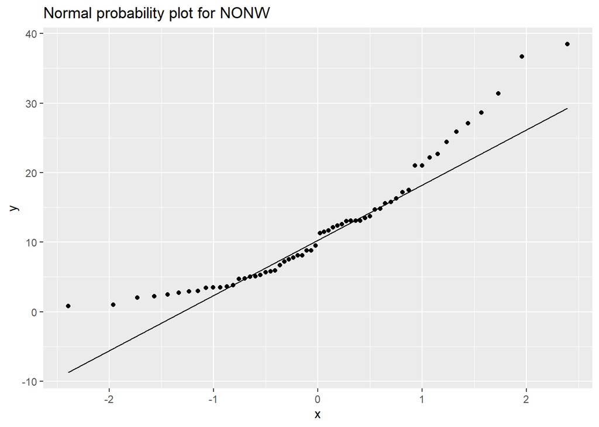

```r
df |> ggplot(aes(sample = NONW)) +
  stat_qq() +
  stat_qq_line() +
  ggtitle("Normal probability plot for NONW")
```

```r
shapiro.test(df$NONW)
```

```
    Shapiro-Wilk normality test

data:  df$NONW
W = 0.89902, p-value = 0.0001212
```

```r
df.log <- df |> mutate(DENS = log(DENS), NONW = log(NONW), POOR = log(POOR), HC = log(HC), NOX = log(NOX), SO2 = log(SO2))
df.log |>
  scatterPlotMatrix(corrPlotType = "Text",
                    plotProperties = list(noCatColor = "Indigo"),
                    slidersPosition = list(dimCount = 6, xStartingDimIndex = 1, yStartingDimIndex = 1),
                    controlWidgets = TRUE, height = 1050, width = 1000)
```

[interactive chart not shown]

## Статистическая сводка для логарифмированных данных

```r
describe(df.log, type = 1, check = FALSE, range = FALSE) |>
  as.data.frame() |>
  mutate(vars = NULL)
```

|  | n | mean | sd | skew | kurtosis | se |
| --- | --- | --- | --- | --- | --- | --- |
| PREC | 60 | 37.366667 | 9.9846775 | -0.78198576 | 1.08074962 | 1.28901633 |
| JANT | 60 | 33.983333 | 10.1688985 | 0.93652493 | 0.90089956 | 1.31279915 |
| JULT | 60 | 74.583333 | 4.7631768 | 0.13326411 | -0.08830705 | 0.61492348 |
| OVR65 | 60 | 8.798333 | 1.4645520 | -0.03325710 | -0.65287903 | 0.18907284 |
| POPN | 60 | 3.263167 | 0.1352523 | -0.47699736 | -0.05808509 | 0.01746100 |
| EDUC | 60 | 10.973333 | 0.8452994 | -0.21926584 | -0.78851744 | 0.10912768 |
| HOUS | 60 | 80.913333 | 5.1413731 | -0.40650405 | 0.25522120 | 0.66374842 |
| DENS | 60 | 8.198521 | 0.3617896 | -0.08492857 | 0.47280550 | 0.04670684 |
| NONW | 60 | 2.159632 | 0.8677874 | -0.53677219 | -0.10219483 | 0.11203087 |
| WWDRK | 60 | 46.081667 | 4.6130431 | 0.09597673 | 0.41131932 | 0.59554130 |

[output cut: 6 more lines]

Видно, что гистограммы прологарифмированных признаков стали чуть больше похожи на плотность нормального распределения, и их коэффициенты асимметрии и эксцесса стали ближе к 0.

## Выявление и удаление выбросов

На графиках зависимостей параметров загрязнения (*HC, NOX, SO2*) и влажности (*HUMID*) можно увидеть отклонения от закономерностей. Например на графике зависимости *SO2* от *NOX* выделяются точки справа от “облака” и под ним, которые портят линейную зависимость этих признаков, а на графике *HUMID* от *NOX* выделяются точки над и под “облаком”.

Чтобы объяснить неоднородность выборки относительно зависимости *SO2* от *NOX*, добавим к данным новую переменную - разницу между июльской и январской температурами и покрасим точки в зависимости от значения этого признака.

```r
df.log <- df.log |> mutate(TDIFF = JULT - JANT)
df.log |>
  scatterPlotMatrix(corrPlotType = "Text",
                    plotProperties = list(noCatColor = "Indigo"),
                    slidersPosition = list(dimCount = 6, xStartingDimIndex = 1, yStartingDimIndex = 1),
                    zAxisDim = "TDIFF",
                    controlWidgets = TRUE, height = 1050, width = 1000)
```

[interactive chart not shown]

Видно, что эта неоднородность объясняется новым признаком разброса температур.

Точки, в которых логарифм *SO2* равен 0, было решено оставить, так как этих точек много, и они являются выбросами только относительно признака *SO2*, который, возможно, будет убран из дальнейшего анализа (за счёт сильной корреляции с другими параметрами загрязнения).

Также за выброс можно считать точку с максимальной январской температурой (*JANT*), так как на графиках зависимости этого признака от признаков *OVR65* и *POPN* эта точка не выглядит как часть закономерности. Однако, из-за сильной корреляции признаков *JULT* и *JANT* последний, возможно, будет убран из будущего анализа, а эта точка подчиняется остальным закономерностям, поэтому её тоже решено было оставить.

### Графики после удаления выбросов:

```r
pollution.outliers <- c(21, 29, 47, 48, 49)
humidity.outliers <- c(18, 29, 41, 48, 49, 50)
so2.zero.outliers <- c(25, 32, 37, 56)
jant.outliers <- c(32)

outliers <- union(pollution.outliers, humidity.outliers)
df.clean <- df.log[-outliers,]
df.clean |>
  scatterPlotMatrix(corrPlotType = "Text",
                    plotProperties = list(noCatColor = "Indigo"),
                    slidersPosition = list(dimCount = 6, xStartingDimIndex = 1, yStartingDimIndex = 1),
                    controlWidgets = TRUE, height = 1050, width = 1000)
```

[interactive chart not shown]

## Статистическая сводка после удаления выбросов:

```r
describe(df.clean, type = 1, check = FALSE, range = FALSE) |>
  as.data.frame() |>
  mutate(vars = NULL)
```

|  | n | mean | sd | skew | kurtosis | se |
| --- | --- | --- | --- | --- | --- | --- |
| PREC | 52 | 39.846154 | 7.1438569 | 0.34340251 | 0.0934201216 | 0.99067470 |
| JANT | 52 | 32.326923 | 9.4385965 | 1.33209204 | 2.7629220402 | 1.30889783 |
| JULT | 52 | 75.326923 | 3.9293823 | 0.58117799 | -0.5516794427 | 0.54490728 |
| OVR65 | 52 | 8.823077 | 1.4766968 | -0.11013246 | -0.6138462005 | 0.20478100 |
| POPN | 52 | 3.289038 | 0.1146907 | -0.29192462 | 0.1652700943 | 0.01590474 |
| EDUC | 52 | 10.807692 | 0.7788494 | -0.14843241 | -0.5766448360 | 0.10800697 |
| HOUS | 52 | 80.153846 | 4.8838052 | -0.53470249 | 0.2993919102 | 0.67726193 |
| DENS | 52 | 8.208786 | 0.3694151 | -0.05806684 | 0.4577706502 | 0.05122865 |
| NONW | 52 | 2.211952 | 0.9008831 | -0.67458922 | -0.0325850757 | 0.12493001 |
| WWDRK | 52 | 45.309615 | 4.4140711 | 0.32694951 | 1.2465326901 | 0.61212152 |

[output cut: 7 more lines]

# Удаление признаков

```r
df.new <- df.clean |> select(-HC, -SO2, -JANT, -JULT, -TDIFF, -WWDRK, -HUMID)
df.new |> colnames() |> print()
```

```
 [1] "PREC"  "OVR65" "POPN"  "EDUC"  "HOUS"  "DENS"  "NONW"  "POOR"  "NOX"
[10] "MORT"
```

# Описание распределений признаков

Добавим новый категориальный признак, разделяющий выборку на группы по количеству осадков (больше/меньше медианы)

```r
df.new <- df.new |> mutate(CLIM = factor(ifelse(PREC > median(PREC), ">.5", "<.5"), levels = c("<.5", ">.5")))
```

## NP-plots для малого количества осадков

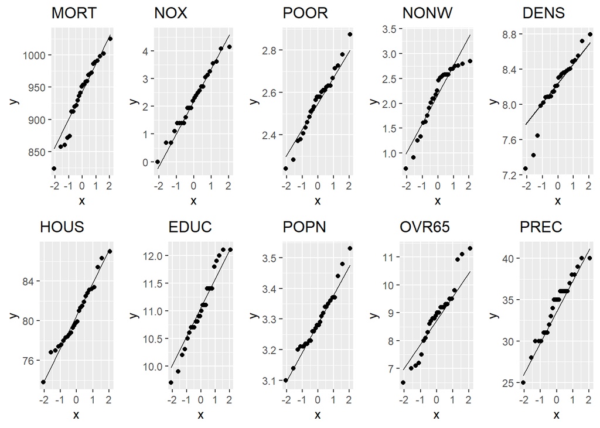

```r
p1 <- df.new |>
  filter(CLIM == "<.5") |>
  ggplot(aes(sample = MORT)) +
  stat_qq() +
  stat_qq_line() +
  ggtitle("MORT")
p2 <- df.new |>
  filter(CLIM == "<.5") |>
  ggplot(aes(sample = NOX)) +
  stat_qq() +
  stat_qq_line() +
  ggtitle("NOX")
p3 <- df.new |>
  filter(CLIM == "<.5") |>
  ggplot(aes(sample = POOR)) +
  stat_qq() +
  stat_qq_line() +
  ggtitle("POOR")
p4 <- df.new |>
  filter(CLIM == "<.5") |>
  ggplot(aes(sample = NONW)) +
  stat_qq() +
  stat_qq_line() +
  ggtitle("NONW")
p5 <- df.new |>
  filter(CLIM == "<.5") |>
  ggplot(aes(sample = DENS)) +
  stat_qq() +
  stat_qq_line() +
  ggtitle("DENS")
p6 <- df.new |>
  filter(CLIM == "<.5") |>
  ggplot(aes(sample = HOUS)) +
  stat_qq() +
  stat_qq_line() +
  ggtitle("HOUS")
p7 <- df.new |>
  filter(CLIM == "<.5") |>
  ggplot(aes(sample = EDUC)) +
  stat_qq() +
  stat_qq_line() +
  ggtitle("EDUC")
p8 <- df.new |>
  filter(CLIM == "<.5") |>
  ggplot(aes(sample = POPN)) +
  stat_qq() +
  stat_qq_line() +
  ggtitle("POPN")
p9 <- df.new |>
  filter(CLIM == "<.5") |>
  ggplot(aes(sample = OVR65)) +
  stat_qq() +
  stat_qq_line() +
  ggtitle("OVR65")
p10 <- df.new |>
  filter(CLIM == "<.5") |>
  ggplot(aes(sample = PREC)) +
  stat_qq() +
  stat_qq_line() +
  ggtitle("PREC")
ggarrange(p1, p2, p3, p4, p5, p6, p7, p8, p9, p10, ncol = 5, nrow = 2)
```

## NP-plots для большого количества осадков

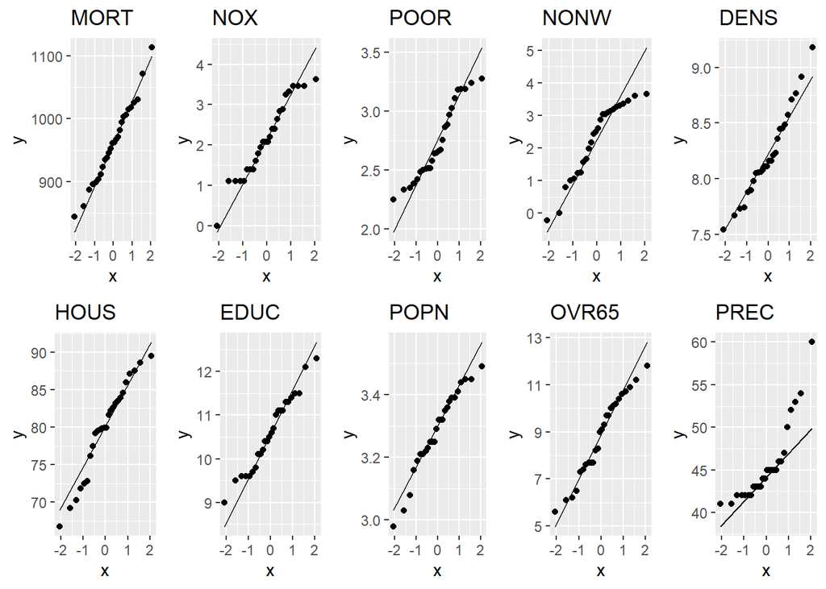

```r
p1 <- df.new |>
  filter(CLIM == ">.5") |>
  ggplot(aes(sample = MORT)) +
  stat_qq() +
  stat_qq_line() +
  ggtitle("MORT")
p2 <- df.new |>
  filter(CLIM == ">.5") |>
  ggplot(aes(sample = NOX)) +
  stat_qq() +
  stat_qq_line() +
  ggtitle("NOX")
p3 <- df.new |>
  filter(CLIM == ">.5") |>
  ggplot(aes(sample = POOR)) +
  stat_qq() +
  stat_qq_line() +
  ggtitle("POOR")
p4 <- df.new |>
  filter(CLIM == ">.5") |>
  ggplot(aes(sample = NONW)) +
  stat_qq() +
  stat_qq_line() +
  ggtitle("NONW")
p5 <- df.new |>
  filter(CLIM == ">.5") |>
  ggplot(aes(sample = DENS)) +
  stat_qq() +
  stat_qq_line() +
  ggtitle("DENS")
p6 <- df.new |>
  filter(CLIM == ">.5") |>
  ggplot(aes(sample = HOUS)) +
  stat_qq() +
  stat_qq_line() +
  ggtitle("HOUS")
p7 <- df.new |>
  filter(CLIM == ">.5") |>
  ggplot(aes(sample = EDUC)) +
  stat_qq() +
  stat_qq_line() +
  ggtitle("EDUC")
p8 <- df.new |>
  filter(CLIM == ">.5") |>
  ggplot(aes(sample = POPN)) +
  stat_qq() +
  stat_qq_line() +
  ggtitle("POPN")
p9 <- df.new |>
  filter(CLIM == ">.5") |>
  ggplot(aes(sample = OVR65)) +
  stat_qq() +
  stat_qq_line() +
  ggtitle("OVR65")
p10 <- df.new |>
  filter(CLIM == ">.5") |>
  ggplot(aes(sample = PREC)) +
  stat_qq() +
  stat_qq_line() +
  ggtitle("PREC")
ggarrange(p1, p2, p3, p4, p5, p6, p7, p8, p9, p10, ncol = 5, nrow = 2)
```

### Тест Шапиро-Уилка на нормальность признаков сгруппированной выборки

```r
df.new |>
  group_by(CLIM) |>
  summarize(NOX = shapiro.test(NOX)$p.value,
            POPN = shapiro.test(POPN)$p.value,
            NONW = shapiro.test(NONW)$p.value,
            POOR = shapiro.test(POOR)$p.value,
            DENS = shapiro.test(DENS)$p.value,
            OVR65 = shapiro.test(OVR65)$p.value,
            HOUS = shapiro.test(HOUS)$p.value,
            EDUC = shapiro.test(EDUC)$p.value,
            MORT = shapiro.test(MORT)$p.value)
```

| CLIM | NOX | POPN | NONW | POOR | DENS | OVR65 | HOUS | EDUC | MORT |
| --- | --- | --- | --- | --- | --- | --- | --- | --- | --- |
| <.5 | 0.9330913 | 0.6536998 | 0.00955825 | 0.94325773 | 0.03432574 | 0.3054417 | 0.7626811 | 0.5899240 | 0.3444604 |
| >.5 | 0.2624711 | 0.3664718 | 0.02603030 | 0.05287064 | 0.55553557 | 0.4264214 | 0.3070279 | 0.6418706 | 0.9837217 |

### Тест Лиллиефорса на нормальность признаков сгруппированной выборки

```r
df.new |>
  group_by(CLIM) |>
  summarize(NOX = lillie.test(NOX)$p.value,
            POPN = lillie.test(POPN)$p.value,
            NONW = lillie.test(NONW)$p.value,
            POOR = lillie.test(POOR)$p.value,
            DENS = lillie.test(DENS)$p.value,
            OVR65 = lillie.test(OVR65)$p.value,
            HOUS = lillie.test(HOUS)$p.value,
            EDUC = lillie.test(EDUC)$p.value,
            MORT = lillie.test(MORT)$p.value)
```

| CLIM | NOX | POPN | NONW | POOR | DENS | OVR65 | HOUS | EDUC | MORT |
| --- | --- | --- | --- | --- | --- | --- | --- | --- | --- |
| <.5 | 0.8481926 | 0.7105771 | 0.01490802 | 0.5785599 | 0.05853154 | 0.2378636 | 0.5504958 | 0.6672277 | 0.4040043 |
| >.5 | 0.6270117 | 0.6600769 | 0.03590403 | 0.1131717 | 0.27772449 | 0.3935144 | 0.1252371 | 0.6242223 | 0.9939923 |

### Тест Андерсона-Дарлинга на нормальность признаков сгруппированной выборки

```r
df.new |>
  group_by(CLIM) |>
  summarize(NOX = ad.test(NOX)$p.value,
            POPN = ad.test(POPN)$p.value,
            NONW = ad.test(NONW)$p.value,
            POOR = ad.test(POOR)$p.value,
            DENS = ad.test(DENS)$p.value,
            OVR65 = ad.test(OVR65)$p.value,
            HOUS = ad.test(HOUS)$p.value,
            EDUC = ad.test(EDUC)$p.value,
            MORT = ad.test(MORT)$p.value)
```

| CLIM | NOX | POPN | NONW | POOR | DENS | OVR65 | HOUS | EDUC | MORT |
| --- | --- | --- | --- | --- | --- | --- | --- | --- | --- |
| <.5 | 0.9500143 | 0.5073536 | 0.01024409 | 0.73199522 | 0.03011584 | 0.1751523 | 0.6015736 | 0.6095711 | 0.2789632 |
| >.5 | 0.3313124 | 0.4933580 | 0.02664927 | 0.05111644 | 0.44842232 | 0.3841954 | 0.2797064 | 0.5331847 | 0.9833432 |

Признаки близкие по распределению к нормальному в обеих группах (нет оснований полагать, что они не нормальны):

1. *NOX*
2. *POPN*
3. *POOR*
4. *OVR65*
5. *HOUS*
6. *EDUC*
7. *MORT*

## Тесты на совпадение распределений в группах по осадкам для выбранных признаков

Сбалансированный дизайн:

```r
df.new |> group_by(CLIM) |> summarize(n = n())
```

| CLIM | n |
| --- | --- |
| <.5 | 26 |
| >.5 | 26 |

### t-test

p-value для проверки гипотезы о равенстве математических ожиданий признаков в зависимости от групп по осадкам

```r
df.new |>
  summarize(NOX = t.test(NOX[CLIM == "<.5"], NOX[CLIM == ">.5"], var.equal = TRUE)$p.value,
            POPN = t.test(POPN[CLIM == "<.5"], POPN[CLIM == ">.5"], var.equal = TRUE)$p.value,
            POOR = t.test(POOR[CLIM == "<.5"], POOR[CLIM == ">.5"], var.equal = TRUE)$p.value,
            OVR65 = t.test(OVR65[CLIM == "<.5"], OVR65[CLIM == ">.5"], var.equal = TRUE)$p.value,
            HOUS = t.test(HOUS[CLIM == "<.5"], HOUS[CLIM == ">.5"], var.equal = TRUE)$p.value,
            EDUC = t.test(EDUC[CLIM == "<.5"], EDUC[CLIM == ">.5"], var.equal = TRUE)$p.value,
            MORT = t.test(MORT[CLIM == "<.5"], MORT[CLIM == ">.5"], var.equal = TRUE)$p.value)
```

| NOX | POPN | POOR | OVR65 | HOUS | EDUC | MORT |
| --- | --- | --- | --- | --- | --- | --- |
| 0.8328237 | 0.820895 | 0.01058587 | 0.940996 | 0.6299954 | 0.04912551 | 0.1664679 |

t-test применим для выборок малой длины, так как выбранные признаки имеют распределения близкие к нормальному. Гипотеза о равенстве математических ожиданий отвергается (при уровне значимости 0.05) только для признаков *POOR* и *EDUC*. Таким образом, можно сказать, что бедность и степень образованности населения связаны с географическим положением региона. Про остальные признаки такого сказать нельзя.

### Проверка симметричности не нормальных признаков

```r
tmp.nonw.l <- ci_skewness(df.new$NONW[df.new$CLIM == "<.5"], seed = 5)$interval
tmp.nonw.m <- ci_skewness(df.new$NONW[df.new$CLIM == ">.5"], seed = 5)$interval
tmp.dens.l <- ci_skewness(df.new$DENS[df.new$CLIM == "<.5"], seed = 5)$interval
tmp.dens.m <- ci_skewness(df.new$DENS[df.new$CLIM == ">.5"], seed = 5)$interval

data.frame(NONW_skew =
             c(paste0("(", tmp.nonw.l[1], ", ", tmp.nonw.l[2], ")"),
               paste0("(", tmp.nonw.m[1], ", ", tmp.nonw.m[2], ")")),
           DENS_skew =
             c(paste0("(", tmp.dens.l[1], ", ", tmp.dens.l[2], ")"),
               paste0("(", tmp.dens.m[1], ", ", tmp.dens.m[2], ")")),
           row.names = c("<.5", ">.5"))
```

|  | NONW_skew | DENS_skew |
| --- | --- | --- |
| <.5 | (-1.74280613117916, -0.323018194343545) | (-1.96127968412638, -0.0758674805066097) |
| >.5 | (-1.46432887932736, -0.0723978663816371) | (-0.0374793156392409, 1.38562661119903) |

В таблице представлены 95%-доверительные интервалы для коэффициента асимметрии признаков в зависимости от количества осадков. О симметричности можно говорить только для признака *DENS* в группе с большим количеством осадков.

Таким образом в отсутствие нормальности и симметричности нельзя проверить равенство математических ожиданий (критерий Виллкокса) или дисперсий (критерий Левена) по группам для признаков *NONW* и *DENS*.

# Зависимости признаков

Ещё раз смотрим на матрицу скаттерплотов:

```r
# df.new |> dplyr::select(-CLIM) |> ggpairs(diag = list(continuous = "barDiag"))
df.new <- df.new[, -32]
df.new |> scatterPlotMatrix(corrPlotType = "Text",
                            plotProperties = list(noCatColor = "Indigo"),
                            slidersPosition = list(dimCount = 10, xStartingDimIndex = 1, yStartingDimIndex = 1),
                            zAxisDim = "CLIM",
                            categoricalCS = "Set1",
                            controlWidgets = TRUE, height = 1050, width = 1000)
```

[interactive chart not shown]

## Значимость коэффициентов корреляции Пирсона

p-value для проверок гипотез о равенстве коэффициентов корреляции нулю:

```r
df.new |>
  select(-CLIM) |>
  rstatix::cor_pmat(method = "pearson")
```

| rowname | PREC | OVR65 | POPN | EDUC | HOUS | DENS | NONW | POOR | NOX | MORT |
| --- | --- | --- | --- | --- | --- | --- | --- | --- | --- | --- |
| PREC | 0.00e+00 | 9.74e-01 | 8.00e-01 | 0.057500 | 5.93e-02 | 0.697000 | 9.80e-02 | 5.06e-06 | 4.84e-01 | 3.21e-02 |
| OVR65 | 9.74e-01 | 0.00e+00 | 5.48e-06 | 0.269000 | 3.20e-01 | 0.365000 | 3.40e-11 | 2.29e-02 | 3.68e-01 | 3.31e-02 |
| POPN | 8.00e-01 | 5.48e-06 | 0.00e+00 | 0.149000 | 1.42e-02 | 0.166000 | 7.18e-03 | 1.23e-01 | 1.19e-01 | 3.78e-02 |
| EDUC | 5.75e-02 | 2.69e-01 | 1.49e-01 | 0.000000 | 6.95e-04 | 0.138000 | 9.67e-01 | 3.64e-03 | 7.43e-02 | 5.90e-03 |
| HOUS | 5.93e-02 | 3.20e-01 | 1.42e-02 | 0.000695 | 0.00e+00 | 0.069800 | 1.17e-01 | 5.64e-09 | 9.92e-01 | 4.18e-02 |
| DENS | 6.97e-01 | 3.65e-01 | 1.66e-01 | 0.138000 | 6.98e-02 | 0.000000 | 6.75e-01 | 3.74e-01 | 7.48e-04 | 3.17e-02 |
| NONW | 9.80e-02 | 3.40e-11 | 7.18e-03 | 0.967000 | 1.17e-01 | 0.675000 | 0.00e+00 | 9.63e-05 | 2.27e-02 | 3.01e-05 |
| POOR | 5.06e-06 | 2.29e-02 | 1.23e-01 | 0.003640 | 5.64e-09 | 0.374000 | 9.63e-05 | 0.00e+00 | 9.57e-01 | 4.16e-03 |
| NOX | 4.84e-01 | 3.68e-01 | 1.19e-01 | 0.074300 | 9.92e-01 | 0.000748 | 2.27e-02 | 9.57e-01 | 0.00e+00 | 1.32e-07 |
| MORT | 3.21e-02 | 3.31e-02 | 3.78e-02 | 0.005900 | 4.18e-02 | 0.031700 | 3.01e-05 | 4.16e-03 | 1.32e-07 | 0.00e+00 |

Для уровня значимости $\alpha=0.05$ значимы корреляции между признаками (в каждом пункте уже прокомментированные связи пропускаются):

- Все коэффициенты корреляции для признака *MORT* значимы.
- *NOX* — *NONW* (скрытый фактор: географические и исторические причины), *DENS* (скрытый фактор: урбанизация)
- *POOR* — *PREC* (скрытый фактор: география), для признаков *OVR65*, *EDUC*, *HOUS* бедность - причина, *NONW* (скрытый фактор: исторические причины)
- *NONW* — *OVR65*, *POPN* (скрытый фактор: бедность?)
- *DENS* больше ни с чем не коррелирует значимо.
- *HOUS* — *POPN*, *EDUC* (скрытый фактор: бедность)
- *EDUC* больше ни с чем не коррелирует значимо
- *POPN* — *OVR65* (скрытый фактор: плотность)
- *OVR65* больше ни с чем не коррелирует значимо

Многие корреляции хоть и значимы, остаются довольно малыми. Из сильных корреляций можно выделить корреляцию между стареющим и небелым населением, процентом безопасных домов и бедностью, а также степенью загрязнения и смертностью.

В отсутствие выбросов, для признаков, близких к нормальным ожидается, что коэффициенты корреляции не изменятся сильно.

Между признаками *NONW* и *POOR* видна слабая монотонная нелинейность, которая может увеличить коэффициент Спирмена относительно Пирсона, однако распределение *POOR* имеет выраженный “хвост”, из-за чего может увеличится коэффициент Пирсона относительно Спирмена. Поэтому в этом случае нельзя сказать об их связи однозначно.

## Коэффициенты корреляции Спирмена

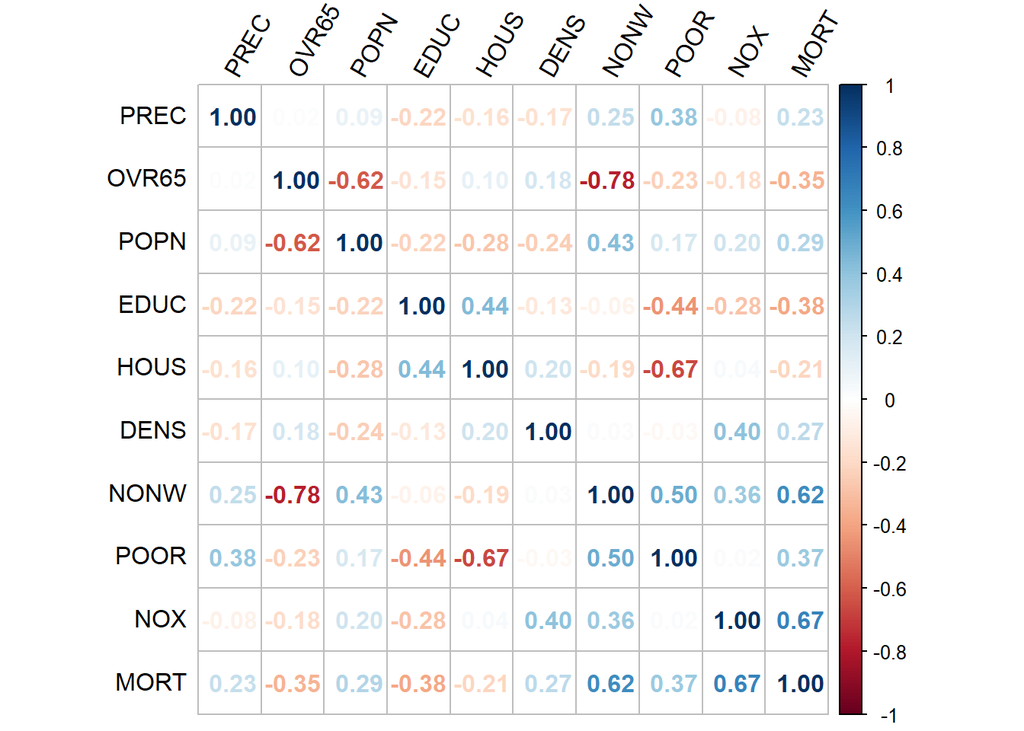

```r
df.new |>
  select(-CLIM) |>
  cor(method = "spearman") |>
  corrplot(method = "number", tl.col = "black", tl.srt = 60)
```

```r
df.new |>
  select(-CLIM) |>
  rstatix::cor_pmat(method = "spearman")
```

| rowname | PREC | OVR65 | POPN | EDUC | HOUS | DENS | NONW | POOR | NOX | MORT |
| --- | --- | --- | --- | --- | --- | --- | --- | --- | --- | --- |
| PREC | 0.00000 | 9.11e-01 | 5.15e-01 | 0.12100 | 2.45e-01 | 0.23900 | 7.40e-02 | 4.93e-03 | 5.96e-01 | 9.73e-02 |
| OVR65 | 0.91100 | 0.00e+00 | 1.11e-06 | 0.28800 | 4.78e-01 | 0.19500 | 1.48e-11 | 9.81e-02 | 2.00e-01 | 1.16e-02 |
| POPN | 0.51500 | 1.11e-06 | 0.00e+00 | 0.11400 | 4.66e-02 | 0.08400 | 1.55e-03 | 2.22e-01 | 1.50e-01 | 3.64e-02 |
| EDUC | 0.12100 | 2.88e-01 | 1.14e-01 | 0.00000 | 1.13e-03 | 0.37200 | 6.56e-01 | 1.05e-03 | 4.17e-02 | 4.97e-03 |
| HOUS | 0.24500 | 4.78e-01 | 4.66e-02 | 0.00113 | 0.00e+00 | 0.15500 | 1.68e-01 | 6.85e-08 | 7.88e-01 | 1.34e-01 |
| DENS | 0.23900 | 1.95e-01 | 8.40e-02 | 0.37200 | 1.55e-01 | 0.00000 | 8.55e-01 | 8.30e-01 | 3.07e-03 | 5.41e-02 |
| NONW | 0.07400 | 1.48e-11 | 1.55e-03 | 0.65600 | 1.68e-01 | 0.85500 | 0.00e+00 | 1.67e-04 | 8.50e-03 | 8.54e-07 |
| POOR | 0.00493 | 9.81e-02 | 2.22e-01 | 0.00105 | 6.85e-08 | 0.83000 | 1.67e-04 | 0.00e+00 | 8.63e-01 | 7.50e-03 |
| NOX | 0.59600 | 2.00e-01 | 1.50e-01 | 0.04170 | 7.88e-01 | 0.00307 | 8.50e-03 | 8.63e-01 | 0.00e+00 | 6.14e-08 |
| MORT | 0.09730 | 1.16e-02 | 3.64e-02 | 0.00497 | 1.34e-01 | 0.05410 | 8.54e-07 | 7.50e-03 | 6.14e-08 | 0.00e+00 |

По сравнению с коэффициентами Пирсона пропала значимость корреляции между признаками:

- *MORT* — *PREC*, *HOUS*, *DENS*
- *POOR* — *OVR65*

Вероятнее всего это объясняется меньшей мощностью критерия, применяющего для построения статистики коэффициент Спирмена.

По сравнению с коэффициентами Пирсона появилась значимость корреляции между признаками:

- *NOX* — *EDUC*

## Частные корреляции смертности с бедностью и образованностью населения за вычетом влияния географического положения (осадков)

Так как t-test показал зависимость параметров бедности и образованности от географического положения, то имеет смысл проверить, сохранятся ли корреляции этих признаков со смертностью, если вычесть влияние осадков.

Частный коэффициент корреляции между *MORT* и *POOR*:

```r
pcor.test(df.new$MORT, df.new$POOR, df.new$PREC)[1:2]
```

| estimate | p.value |
| --- | --- |
| 0.2799244 | 0.04664926 |

Частный коэффициент корреляции между *MORT* и *EDUC*:

```r
pcor.test(df.new$MORT, df.new$EDUC, df.new$PREC)[1:2]
```

| estimate | p.value |
| --- | --- |
| -0.3235982 | 0.02053801 |

Частные коэффициенты корреляции уменьшились по модулю по сравнению с коэффициентами корреляции Пирсона, но всё ещё остались значимыми.